```python
import numpy as np
import scipy.stats as stats
import pandas as pd

import matplotlib.pyplot as plt
import matplotlib.pylab as pylab

plt.style.use('fivethirtyeight')
pylab.rcParams['figure.figsize'] = 13, 6
np.random.seed(1234)
```

# Evaluation of medGAN Results

## Data

This is using the MIMIC dataset and looking at the `ADMISSIONS` table versus the `DIAGNOSIS` table. Each matrix has rows that are patients and columns that are ICD-9 codes. There are two versions that the medGAN system can work with, either a binary version or a count version. In the binary version every value is either 0 or 1 indicating whether the patient has the diagnosis or not. In the count version we can actually see the number of times that diagnosis appears for each patient.

## Binary Comparison

First, we will look at the binary data version. Below we grab the original binary data and the synthetic binary data and read it in. Then we can look at the shape of each and basic stats about the matrices

```python
orig_data = np.load('data/binary.matrix')
synth_data = np.load('data/synthetic_binary_out.npy')

print("Shapes:")
print("Original Data:\t{}".format(orig_data.shape))
print("Synthetic Data:\t{}".format(synth_data.shape), end="\n\n")

print("Sparsity:")
print("Original Data:\t{}".format(np.count_nonzero(orig_data) / orig_data.size))
print("Synthetic Data:\t{}".format(np.count_nonzero(synth_data) / synth_data.size))
```

```
Shapes:
Original Data:	(46520, 1071)
Synthetic Data:	(10000, 1071)

Sparsity:
Original Data:	0.010519174709149925
Synthetic Data:	0.9999823529411764
```

```python
synth_data_binomial = np.random.binomial(1, synth_data)

print("Sparsity:")
print("Original Data:\t{}".format(np.count_nonzero(orig_data) / orig_data.size))
print("Synthetic Data:\t{}".format(np.count_nonzero(synth_data_binomial) / synth_data_binomial.size))
```

```
Sparsity:
Original Data:	0.010519174709149925
Synthetic Data:	0.010879365079365079
```

By doing that we can see we now have a very similar sparisty in the matrices.

## Dimension-wise probability performance

One of the metrics used in the paper to measure performance is Dimension-wise probability, described as below.

> This is a basic sanity check to confirm the model has learned each dimension’s distribution correctly. We use the training set $R$ to train the models, then generate the same number of synthetic samples $S$. Using $R$ and $S$, we compare the Bernoulli success probability $p_k$ of each dimension $k$.

Using this check we can compare the two matrices in the plot below.

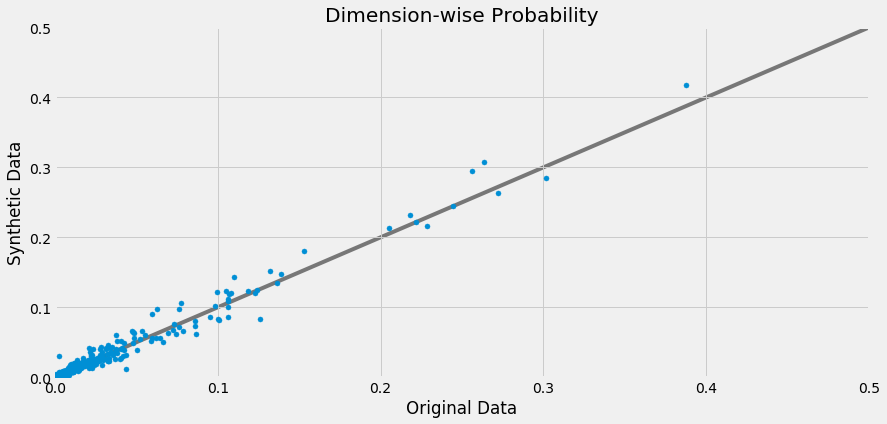

```python
orig_col_avg = np.sum(orig_data, 0) / orig_data.shape[0]
synth_col_avg = np.sum(synth_data_binomial, 0) / synth_data_binomial.shape[0]
synth_col_avg_binomial = np.sum(synth_data_binomial, 0) / synth_data_binomial.shape[0]

plt.scatter(orig_col_avg, synth_col_avg_binomial, s=25, zorder=10)
lims = [0, .5]
plt.xlim(lims)
plt.ylim(lims)
plt.plot(lims, lims, 'k-', alpha=0.5, zorder=0)
plt.xlabel("Original Data")
plt.ylabel("Synthetic Data")
plt.title("Dimension-wise Probability")
plt.show()
```

From the plot above we can see that we have a pretty close match on the probability distributions. This seems to result mainly from the fact that these distributions are pretty close to begin with. To verify that the distributions are the same though we can use a paired t-test to check if they are different.

```python
print('Difference in variances {:06.10f}'.format(np.abs(np.var(orig_col_avg) - np.var(synth_col_avg_binomial))))
print('Paired t-test p-value {:06.5f}'.format(stats.ttest_rel(orig_col_avg, synth_col_avg_binomial).pvalue))
```

```
Difference in variances 0.0000861929
Paired t-test p-value 0.01762
```

Now that we have looked at the columns we can start to look at the rows to see if that also matches.

## Row Distribution

We will be comparing the row distributions differently from the columns. This is because each row doesn't need to have the same distribution, but we can look at the sums of the rows throughout the data to see how the counts compare to the counts in the synthetic data. We also have to scale these to be densities instead of frequencies to account for the fact that the sample sizes are different.

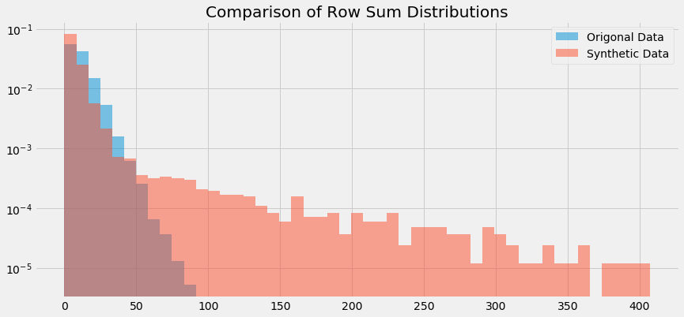

```python
x = orig_data.sum(1)
y = synth_data_binomial.sum(1)

bins = np.linspace(0, np.max([x.max(), y.max()]), 50)

plt.hist(x, bins, alpha=0.5, label='Origonal Data', log=True, density=True)
plt.hist(y, bins, alpha=0.5, label='Synthetic Data', log=True, density=True)
plt.legend(loc='upper right')
plt.title('Comparison of Row Sum Distributions')
plt.show()
```

From this we can see that the densities match for a little bit but then the tail of the synthetic data is much longer than the real data. This could contribute to some of the errors that the authors were saying they saw in the data. For instance a diagnosis for a male only disease and female only disease in the same patient. There are clearly some patients who have too many diagnosis in this data.

```python
print('Two sample t-test p-value {:06.5f}'.format(stats.ttest_ind(x, y).pvalue))
```

```
Two sample t-test p-value 0.01046
```

## Logistic Regression Test

This logistic regression test tries every column as the predicted column and tries to use the rest of the data to predict that column. The model is fitted on the origional data and then tested on the origonal data and the synthetic data. This does present problems of overfitting to the training data, but with the sparsity so small there were issues splitting the data and fitting on data without both classes. Even with the overfitting potential the data is resulting classification rate is still very good and similar across the two data sets.

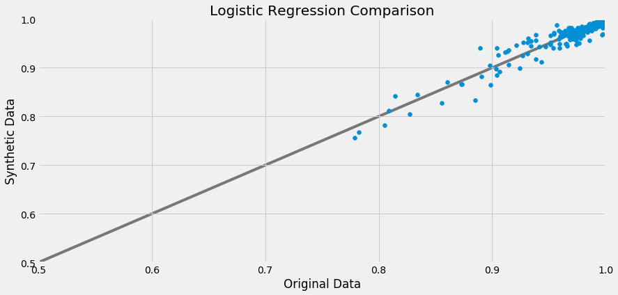

```python
res = pd.read_pickle('logistic_regression_compare')
plt.scatter(res['Origonal Data'], res['Synthentic Data'])
bot, top = .5, 1
plt.xlim([bot, top])
plt.ylim([bot, top])
lims = [bot, top]
plt.plot(lims, lims, 'k-', alpha=0.5, zorder=0)
plt.xlabel("Original Data")
plt.ylabel("Synthetic Data")
plt.title("Logistic Regression Comparison")
plt.show()
```

```python
print('Difference in variances {:06.10f}'.format(np.abs(np.var(res['Origonal Data']) - np.var(res['Synthentic Data']))))
print('Paired t-test p-value {:06.5f}'.format(stats.ttest_rel(res['Origonal Data'], res['Synthentic Data']).pvalue))

print('Difference in averages {:06.5f}'.format(np.mean(res['Origonal Data']) - np.mean(res['Synthentic Data'])))
print('Variance of the origonal data {:06.5f}'.format(np.var(res['Origonal Data'])))
```

```
Difference in variances 0.0000381800
Paired t-test p-value 0.00015
Difference in averages 0.00067
Variance of the origonal data 0.00052
```

Based on the low p-value in the above test we can reject the null hypothesis that these distributions are the same at the 0.01 significance level. From there we can see that the origonal data has a slightly higher average score and is therefore performing better. With that small of a difference I don't think it is that monumental that these are from different distributions especially because the variances are very small.

## Linear Regression

I also tried a linear regression test. In this test I created random weights from -1 to 1 for the each column of the matrix. Then I used those weights to create a prediction column for both the origonal data and the synthetic data. What I found was that the weights are slightly different but the predictions are the same. This is because, at least for the random seed being used, the origonal data is of rank 1070 instead of 1071 and for the synthtic data the rank is lower at around 880.

```python
from linear_regression import LinearRegression

lr = LinearRegression(orig_data, synth_data_binomial)
lr.create_prediction()
lr.test_prediction()
```

```python
print('Norm difference between origonal data regression weights and created weights', end='\n\t')
print(np.linalg.norm(lr.train_res[0] - lr.weights))

print('Norm difference between synthetic data regression weights and created weights', end='\n\t')
print(np.linalg.norm(lr.weights - lr.gen_res[0]))

print('Norm difference between origonal data regression weights and synthetic data regression weights', end='\n\t')
print(np.linalg.norm(lr.train_res[0] - lr.gen_res[0]))

print('Check that all reconstructions are accurate', end='\n\t')
print('Origonal and Created Weights', end='\t\t')
print(np.allclose(lr.train.dot(lr.weights), lr.train_pred), end='\n\t')
print('Origonal and Regression Weights', end='\t\t')
print(np.allclose(lr.train.dot(lr.train_res[0]), lr.train_pred), end='\n\t')

print('Synthetic and Created Weights', end='\t\t')
print(np.allclose(lr.gen.dot(lr.weights), lr.gen_pred), end='\n\t')
print('Synthetic and Regression Weights', end='\t')
print(np.allclose(lr.gen.dot(lr.gen_res[0]), lr.gen_pred))

print()
print('Origonal data estimated rank {}'.format(lr.train_res[2]))
print('Synthetic data estimated rank {}'.format(lr.gen_res[2]))
```

```
Norm difference between origonal data regression weights and created weights
	0.29334783433659406
Norm difference between synthetic data regression weights and created weights
	7.667939836774101
Norm difference between origonal data regression weights and synthetic data regression weights
	7.66710749741359
Check that all reconstructions are accurate
	Origonal and Created Weights		True
	Origonal and Regression Weights		True
	Synthetic and Created Weights		True
	Synthetic and Regression Weights	True

Origonal data estimated rank 1070
Synthetic data estimated rank 887
```